# Working with NHDPlusHR

dblodgett@usgs.gov

## TL;DR;

Most functions in `nhdplusTools` work with NHDPlus High Res (HR) the same as they do with medium res. The demo below shows how to get a single four-digit hydrologic unit worth of HR data, index a point to it, subset it, and plot the results.

*Note: For consistency, identifiers from NHDPlusV2 are used with HiRes data. A future release of nhdplusTools may alter this behavior.*

```
#> Zoom: 10
#> Audotdetect projection: assuming Google Mercator (epsg 3857)
```

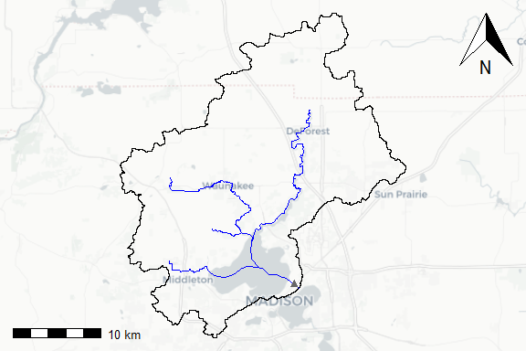

```r
library(nhdplusTools)
library(sf)

work_dir <- file.path(nhdplusTools_data_dir(), "hr_v_cache")

source(system.file("extdata/sample_data.R", package = "nhdplusTools"))

hr_gpkg <- file.path(work_dir, "hr_data.gpkg")

# Make a plot and get some background NHDPlusV2 data.
plot_data <- plot_nhdplus(list("nwissite", "USGS-05428500"), streamorder = 3,
                          nhdplus_data = sample_data,
                          stoponlargerequest = FALSE)
```

```r
# Find the HU04 we are interested in.
hu04 <- unique(substr(plot_data$flowline$REACHCODE, 1, 4))

# Download some NHDPlusHR Data
hr_data_dir <- download_nhdplushr(work_dir, hu04)

# Projection and simplification for demo purposes.
hr <- get_nhdplushr(work_dir, out_gpkg = hr_gpkg,
                    proj = 3857)

(start_index <- get_flowline_index(st_transform(hr$NHDFlowline, 5070),
                                   st_transform(plot_data$outlets, 5070),
                                   search_radius = 200)) # meters albers eq area
```

```
#> # A tibble: 1 x 5
#>      id   COMID REACHCODE      REACH_meas offset
#>   <int>   <dbl> <chr>               <dbl>  <dbl>
#> 1     1 2.20e13 07090002006114       37.7   87.7
```

```r
ids <- get_UT(hr$NHDFlowline, start_index$COMID)

hr_subset <- subset_nhdplus(ids, nhdplus_data = hr_gpkg)
```

```
#> All intersections performed in latitude/longitude.
#> Reading NHDFlowline
#> 366 comids of 366
#> Writing NHDFlowline
#> Reading NHDPlusCatchment
#> 366 comids of 366
#> Found invalid geometry, attempting to fix.
#> Writing NHDPlusCatchment
```

Now that we have both a four digit hydrologic unit worth of NHDPlusHR data and a subset upstream of a point of interest, we can plot things up and see what it looks like. This plot uses NHDPlusV2 as returned by `plot_nhdplus()` as a base layer and adds NHDPlusHR data on top of it.

```r
plot_nhdplus(list("nwissite", "USGS-05428500"), streamorder = 2,
             nhdplus_data = sample_data, overwrite = TRUE,
             plot_config = list(flowline = list(lwd = 2.5),
                                basin = list(lwd = 3)),
             stoponlargerequest = FALSE)
```

```
#> Zoom: 10
#> Audotdetect projection: assuming Google Mercator (epsg 3857)
```

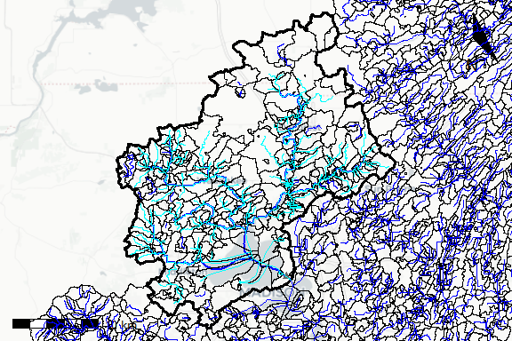

```r
plot(st_geometry(hr$NHDPlusCatchment), lwd = 0.25, add = TRUE)
plot(st_geometry(hr$NHDFlowline), col = "blue", lwd = 0.5, add = TRUE)

plot(st_geometry(st_transform(hr_subset$NHDFlowline, 3857)),
     col = "cyan", lwd = 1, add = TRUE)
```

## Download

NHDPlusHR support in nhdplusTools begins with the function `download_nhdplushr()`. The NHDPlusHR can be downloaded in [four digit hydrologic unit code subsets here.](https://www.usgs.gov/core-science-systems/ngp/national-hydrography/access-national-hydrography-products) `download_nhdplushr()` facilitates downloading these subsets for as few or as many as you need. It takes a directory you want to save your output into and a vector of four digit (HU04) or two digit (HU02) hydrologic units. There is also an option to just return the URLs of the data that would be downloaded for you to use in some other process. Since the TL;DR; above already downloaded some data. The code below shows how to just get the URLs for a whole HU02 and what the output looks like on disk.

*Note: Data for each HU02 are put in their own output folder.*

```r
(hr_urls <- download_nhdplushr(work_dir, "06", download_files = FALSE))
```

```
#> [1] "https://prd-tnm.s3.amazonaws.com/StagedProducts/Hydrography/NHDPlusHR/Beta/GDB/NHDPLUS_H_0601_HU4_GDB.zip"
#> [2] "https://prd-tnm.s3.amazonaws.com/StagedProducts/Hydrography/NHDPlusHR/Beta/GDB/NHDPLUS_H_0602_HU4_GDB.zip"
#> [3] "https://prd-tnm.s3.amazonaws.com/StagedProducts/Hydrography/NHDPlusHR/Beta/GDB/NHDPLUS_H_0603_HU4_GDB.zip"
#> [4] "https://prd-tnm.s3.amazonaws.com/StagedProducts/Hydrography/NHDPlusHR/Beta/GDB/NHDPLUS_H_0604_HU4_GDB.zip"
```

```r
# already downloaded:
list.files(hr_data_dir)
```

```
#> [1] "NHDPLUS_H_0709_HU4_GDB.gdb" "NHDPLUS_H_0709_HU4_GDB.jpg"
#> [3] "NHDPLUS_H_0709_HU4_GDB.xml"
```

## Basic functionality

The second part of nhdplusTools support for NHDPlusHR is a bit more involved. The entry point is a function called `get_nhdplushr()`. At it’s core, it will take a collection of NHDPlusHR subsets, open them up one by one and build a single output table for later use. It also 1. joins flowline attributes to the flowline geometry, 1. can return one or more selected layers, 1. can save the result to a standalone geopackage for later use, and 1. can make some attributes of a subset look like they are part of a standalone network rather than having references to downstream data that aren’t in the subset.

Using the data we downloaded in the TL;DR; intro, the code below demonstrates a few behaviors of `get_nhdplushr()`

First, if we just give it a directory containing HR data, it will give us back a list with flowlines and catchments as sf data.frames.

```r
hr <- get_nhdplushr(hr_data_dir)
sapply(hr, class)
```

```
#>      NHDFlowline  NHDPlusCatchment
#> [1,] "sf"         "sf"
#> [2,] "tbl_df"     "tbl_df"
#> [3,] "tbl"        "tbl"
#> [4,] "data.frame" "data.frame"
```

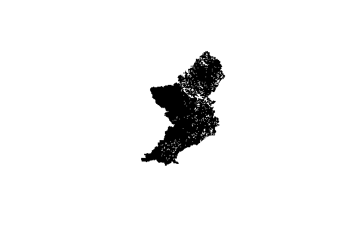

```r
plot(st_geometry(hr$NHDFlowline), lwd = (hr$NHDFlowline$StreamOrde / 6))
```

If we want more data, we can get any of the layer options listed in the `get_nhdplushr()` documentation.

```r
hr <- get_nhdplushr(hr_data_dir, layers = c("NHDFlowline", "NHDWaterbody", "NHDArea"))
sapply(hr, class)
```

```
#>      NHDFlowline  NHDWaterbody NHDArea
#> [1,] "sf"         "sf"         "sf"
#> [2,] "tbl_df"     "tbl_df"     "tbl_df"
#> [3,] "tbl"        "tbl"        "tbl"
#> [4,] "data.frame" "data.frame" "data.frame"
```

```r
sapply(hr, nrow)
```

```
#>  NHDFlowline NHDWaterbody      NHDArea
#>        34532        11444          499
```

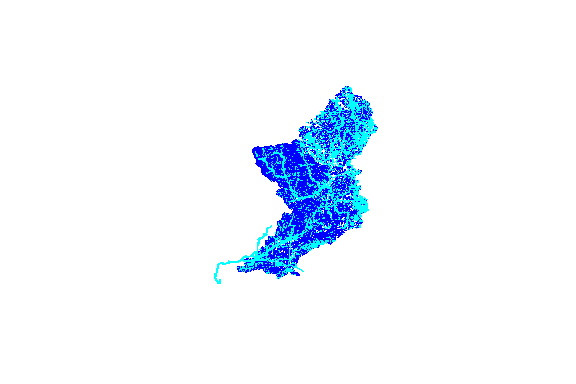

```r
plot(st_geometry(hr$NHDFlowline), lwd = (hr$NHDFlowline$StreamOrde / 6), col = "blue")

plot(c(st_geometry(hr$NHDWaterbody), st_geometry(hr$NHDArea)),
     col = "cyan", border = "cyan", lwd = 0.25, add = TRUE)
```

Since this function can work over large amounts of data and we don’t want to keep running it again and again, there is an option to save the results to a standalone database for later use.

```r
demo_gpkg <- file.path(work_dir, "demo.gpkg")
hr <- get_nhdplushr(hr_data_dir, out_gpkg = demo_gpkg)
st_layers(demo_gpkg)
```

```
#> Driver: GPKG
#> Available layers:
#>         layer_name     geometry_type features fields
#> 1      NHDFlowline Multi Line String    34532     57
#> 2 NHDPlusCatchment     Multi Polygon    42300      7
```

## HR modification and filtering

*Note: These options only operate on the flowline network.*

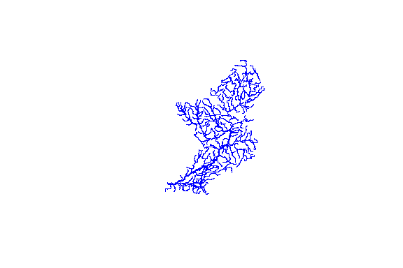

```r
demo <- get_nhdplushr(hr_data_dir, layers = "NHDFlowline",
                               min_size_sqkm = 50)
plot(st_geometry(demo$NHDFlowline),
     lwd = demo$NHDFlowline$StreamOrde/4, col = "blue")
```

```r
demo <- get_nhdplushr(hr_data_dir, layers = "NHDFlowline",
                      min_size_sqkm = 100,
                      proj = "+init=epsg:5070", simp = 200,
                      keep_cols = c("COMID", "StreamOrde"))
names(demo$NHDFlowline)
```

```
#> [1] "COMID"      "StreamOrde" "Shape"
```

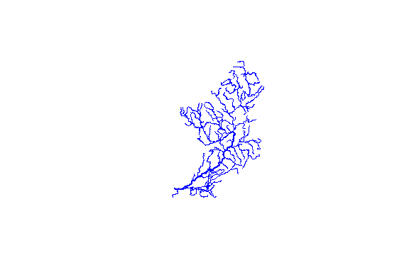

```r
plot(st_geometry(demo$NHDFlowline),
     lwd = demo$NHDFlowline$StreamOrde/4, col = "blue")
```

## Make Standalone Basins

The NHDPlus data model has some shared identifiers that can span very large distances. For example, the “Level Path Identifier” identifies an entire river from headwater to outlet using the “hydrologic sequence identifier” of the outlet. Similarly, the “Terminal Path Identifier” identifies an entire basin using the hydrologic sequence identifier of the terminal flowline (to the ocean or an inland sink). When creating subsets of NHDPlus data, many times, these attributes can identify flowlines that are not included in the subset. For most applications, this is not a problem, but in some cases, it is advantageous to adjust identifiers such that the subset appears to be a complete drainage basin with a true terminal outlet. `make_standalone()` accomplishes this task.

On a one by one basis, this may seam insignificant, but for workflows that need to work with arbitrary subsets and start from basin outlets, this functionality is useful. It has little impact on the data and is applied by default.

The example below shows how the outlet is modified. As described in the documentation os `make_standalone()` all related attributes upstream are also fixed such that the network is intact for further use.

```r
demo <- get_nhdplushr(hr_data_dir, layers = "NHDFlowline",
                    min_size_sqkm = 100, check_terminals = FALSE)

# Create a standalone basin with the results for comparison.
standalone_demo <- make_standalone(demo$NHDFlowline)

demo_outlet <- dplyr::filter(demo$NHDFlowline, TotDASqKM == max(TotDASqKM))

standalone_demo_outlet <- dplyr::filter(standalone_demo, TotDASqKM == max(TotDASqKM))

broken_outlet <- dplyr::select(st_drop_geometry(demo_outlet),
                               Hydroseq, TerminalPa, TerminalFl, LevelPathI)
fixed_outlet <- dplyr::select(st_drop_geometry(standalone_demo_outlet),
                              Hydroseq, TerminalPa, TerminalFl, LevelPathI)

print(data.frame(broken_outlet))
```

```
#>         Hydroseq     TerminalPa TerminalFl     LevelPathI
#> 1 22001000000414 22000100000212          0 22000300045683
```

```r
print(data.frame(fixed_outlet))
```

```
#>         Hydroseq     TerminalPa TerminalFl     LevelPathI
#> 1 22001000000414 22001000000414          1 22001000000414
```

```r
(broken <- dplyr::filter(demo$NHDFlowline, TerminalPa == demo_outlet$Hydroseq))
```

```
#> Simple feature collection with 0 features and 57 fields
#> Bounding box:  xmin: NA ymin: NA xmax: NA ymax: NA
#> Geodetic CRS:  NAD83
#> # A tibble: 0 x 58
#> # ... with 58 variables: Permanent_Identifier <chr>, FDate <dttm>,
#> #   Resolution <int>, GNIS_ID <chr>, GNIS_Name <chr>, LENGTHKM <dbl>,
#> #   REACHCODE <chr>, FlowDir <int>, WBArea_Permanent_Identifier <chr>,
#> #   FTYPE <int>, FCODE <int>, MainPath <int>, InNetwork <int>,
#> #   VisibilityFilter <int>, Shape_Length <dbl>, COMID <dbl>, VPUID <chr>,
#> #   Enabled <int>, Shape <GEOMETRY [°]>, StreamLeve <int>, StreamOrde <int>,
#> #   StreamCalc <int>, FromNode <dbl>, ToNode <dbl>, Hydroseq <dbl>,
#> #   LevelPathI <dbl>, Pathlength <dbl>, TerminalPa <dbl>, ArbolateSu <dbl>,
#> #   Divergence <int>, StartFlag <int>, TerminalFl <int>, UpLevelPat <dbl>,
#> #   UpHydroSeq <dbl>, DnLevel <int>, DnLevelPat <dbl>, DnHydroseq <dbl>,
#> #   DnMinorHyd <dbl>, DnDrainCou <int>, FromMeas <dbl>, ToMeas <dbl>,
#> #   RtnDiv <int>, Thinner <int>, VPUIn <int>, VPUOut <int>, AreaSqKM <dbl>,
#> #   TotDASqKM <dbl>, DivDASqKm <dbl>, MaxElevRaw <dbl>, MinElevRaw <dbl>,
#> #   MaxElevSmo <dbl>, MinElevSmo <dbl>, Slope <dbl>, SlopeLenKm <dbl>,
#> #   ElevFixed <int>, HWType <int>, HWNodeSqKm <dbl>, StatusFlag <chr>
```

```r
(standalone <- dplyr::filter(standalone_demo, TerminalPa == standalone_demo_outlet$Hydroseq))
```

```
#> Simple feature collection with 5358 features and 57 fields
#> Geometry type: MULTILINESTRING
#> Dimension:     XY
#> Bounding box:  xmin: -90.68076 ymin: 41.27482 xmax: -88.1999 ymax: 43.74949
#> Geodetic CRS:  NAD83
#> # A tibble: 5,358 x 58
#>    Permanent_Identi~ FDate               Resolution GNIS_ID GNIS_Name   LENGTHKM
#>  * <chr>             <dttm>                   <int> <chr>   <chr>          <dbl>
#>  1 156038282         2012-03-19 01:32:25          2 004155~ Pecatonica~    1.34
#>  2 155714162         2014-10-28 19:00:00          2 004248~ Fairfield ~    0.417
#>  3 156035374         2012-03-19 01:35:08          2 015619~ Gordon Cre~    0.39
#>  4 145600320         2012-03-19 01:34:47          2 004168~ Rock Creek     0.352
#>  5 155712981         2012-03-19 02:05:43          2 <NA>    <NA>           0.034
#>  6 137417698         2012-03-18 13:07:30          2 015750~ Sugar River    0.798
#>  7 156037500         2012-03-19 01:33:10          2 <NA>    <NA>           0.009
#>  8 145599800         2012-03-19 01:34:47          2 004145~ North Fork~    0.665
#>  9 143246785         2012-03-18 12:56:42          2 004168~ Rock River     0.165
#> 10 155712415         2012-03-19 02:05:51          2 004241~ Willow Cre~    2.11
#> # ... with 5,348 more rows, and 52 more variables: REACHCODE <chr>,
#> #   FlowDir <int>, WBArea_Permanent_Identifier <chr>, FTYPE <int>, FCODE <int>,
#> #   MainPath <int>, InNetwork <int>, VisibilityFilter <int>,
#> #   Shape_Length <dbl>, COMID <dbl>, VPUID <chr>, Enabled <int>,
#> #   Shape <MULTILINESTRING [°]>, StreamLeve <int>, StreamOrde <int>,
#> #   StreamCalc <int>, FromNode <dbl>, ToNode <dbl>, Hydroseq <dbl>,
#> #   LevelPathI <dbl>, Pathlength <dbl>, TerminalPa <dbl>, ArbolateSu <dbl>,
#> #   Divergence <int>, StartFlag <int>, TerminalFl <dbl>, UpLevelPat <dbl>,
#> #   UpHydroSeq <dbl>, DnLevel <dbl>, DnLevelPat <dbl>, DnHydroseq <dbl>,
#> #   DnMinorHyd <dbl>, DnDrainCou <int>, FromMeas <dbl>, ToMeas <dbl>,
#> #   RtnDiv <int>, Thinner <int>, VPUIn <int>, VPUOut <int>, AreaSqKM <dbl>,
#> #   TotDASqKM <dbl>, DivDASqKm <dbl>, MaxElevRaw <dbl>, MinElevRaw <dbl>,
#> #   MaxElevSmo <dbl>, MinElevSmo <dbl>, Slope <dbl>, SlopeLenKm <dbl>,
#> #   ElevFixed <int>, HWType <int>, HWNodeSqKm <dbl>, StatusFlag <chr>
```

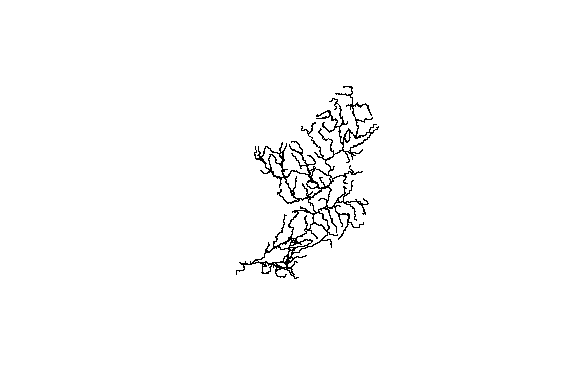

```r
plot(st_geometry(standalone))
```